# Risk Factor Analysis

## Outcome Variable

**Outcome Variable:** y_rate_len

## Predictor Variables

**Intervention Variable:** cleanck

**Adjustment Set:**

unadjusted

## Stratifying Variables

The analysis was stratified on these variable(s):

- agecat
- studyid
- country

## Data Summary

| agecat | studyid | country | cleanck | n_cell | n |
| --- | --- | --- | --- | --- | --- |
| 0-3 months | ki1017093b-PROVIDE | BANGLADESH | 0 | 109 | 634 |
| 0-3 months | ki1017093b-PROVIDE | BANGLADESH | 1 | 525 | 634 |
| 0-3 months | ki1017093c-NIH-Crypto | BANGLADESH | 0 | 213 | 546 |
| 0-3 months | ki1017093c-NIH-Crypto | BANGLADESH | 1 | 333 | 546 |
| 0-3 months | ki1000108-CMC-V-BCS-2002 | INDIA | 0 | 48 | 87 |
| 0-3 months | ki1000108-CMC-V-BCS-2002 | INDIA | 1 | 39 | 87 |
| 0-3 months | ki1000108-IRC | INDIA | 0 | 157 | 369 |
| 0-3 months | ki1000108-IRC | INDIA | 1 | 212 | 369 |
| 0-3 months | ki0047075b-MAL-ED | PERU | 1 | 1 | 1 |
| 0-3 months | ki0047075b-MAL-ED | SOUTH AFRICA | 0 | 1 | 2 |
| 0-3 months | ki0047075b-MAL-ED | SOUTH AFRICA | 1 | 1 | 2 |
| 3-6 months | ki1017093b-PROVIDE | BANGLADESH | 0 | 99 | 574 |
| 3-6 months | ki1017093b-PROVIDE | BANGLADESH | 1 | 475 | 574 |
| 3-6 months | ki1017093c-NIH-Crypto | BANGLADESH | 0 | 212 | 527 |
| 3-6 months | ki1017093c-NIH-Crypto | BANGLADESH | 1 | 315 | 527 |
| 3-6 months | ki1000108-CMC-V-BCS-2002 | INDIA | 0 | 174 | 307 |
| 3-6 months | ki1000108-CMC-V-BCS-2002 | INDIA | 1 | 133 | 307 |
| 3-6 months | ki1000108-IRC | INDIA | 0 | 166 | 390 |
| 3-6 months | ki1000108-IRC | INDIA | 1 | 224 | 390 |
| 3-6 months | ki1113344-GMS-Nepal | NEPAL | 0 | 420 | 426 |
| 3-6 months | ki1113344-GMS-Nepal | NEPAL | 1 | 6 | 426 |
| 3-6 months | ki0047075b-MAL-ED | SOUTH AFRICA | 1 | 1 | 1 |
| 6-12 months | ki1017093b-PROVIDE | BANGLADESH | 0 | 96 | 545 |
| 6-12 months | ki1017093b-PROVIDE | BANGLADESH | 1 | 449 | 545 |
| 6-12 months | ki1017093c-NIH-Crypto | BANGLADESH | 0 | 214 | 516 |
| 6-12 months | ki1017093c-NIH-Crypto | BANGLADESH | 1 | 302 | 516 |
| 6-12 months | ki1000108-CMC-V-BCS-2002 | INDIA | 0 | 185 | 323 |
| 6-12 months | ki1000108-CMC-V-BCS-2002 | INDIA | 1 | 138 | 323 |
| 6-12 months | ki1000108-IRC | INDIA | 0 | 164 | 391 |
| 6-12 months | ki1000108-IRC | INDIA | 1 | 227 | 391 |
| 6-12 months | ki1113344-GMS-Nepal | NEPAL | 0 | 420 | 428 |
| 6-12 months | ki1113344-GMS-Nepal | NEPAL | 1 | 8 | 428 |
| 6-12 months | ki0047075b-MAL-ED | SOUTH AFRICA | 1 | 1 | 1 |
| 12-24 months | ki1017093b-PROVIDE | BANGLADESH | 0 | 80 | 458 |
| 12-24 months | ki1017093b-PROVIDE | BANGLADESH | 1 | 378 | 458 |
| 12-24 months | ki1017093c-NIH-Crypto | BANGLADESH | 0 | 211 | 396 |
| 12-24 months | ki1017093c-NIH-Crypto | BANGLADESH | 1 | 185 | 396 |
| 12-24 months | ki1000108-CMC-V-BCS-2002 | INDIA | 0 | 191 | 324 |
| 12-24 months | ki1000108-CMC-V-BCS-2002 | INDIA | 1 | 133 | 324 |
| 12-24 months | ki1000108-IRC | INDIA | 0 | 163 | 387 |
| 12-24 months | ki1000108-IRC | INDIA | 1 | 224 | 387 |
| 12-24 months | ki1113344-GMS-Nepal | NEPAL | 0 | 323 | 328 |
| 12-24 months | ki1113344-GMS-Nepal | NEPAL | 1 | 5 | 328 |
| 12-24 months | ki0047075b-MAL-ED | SOUTH AFRICA | 1 | 1 | 1 |

The following strata were considered:

- agecat: 0-3 months, studyid: ki0047075b-MAL-ED, country: PERU
- agecat: 0-3 months, studyid: ki0047075b-MAL-ED, country: SOUTH AFRICA
- agecat: 0-3 months, studyid: ki1000108-CMC-V-BCS-2002, country: INDIA
- agecat: 0-3 months, studyid: ki1000108-IRC, country: INDIA
- agecat: 0-3 months, studyid: ki1017093b-PROVIDE, country: BANGLADESH
- agecat: 0-3 months, studyid: ki1017093c-NIH-Crypto, country: BANGLADESH
- agecat: 12-24 months, studyid: ki0047075b-MAL-ED, country: SOUTH AFRICA
- agecat: 12-24 months, studyid: ki1000108-CMC-V-BCS-2002, country: INDIA
- agecat: 12-24 months, studyid: ki1000108-IRC, country: INDIA
- agecat: 12-24 months, studyid: ki1017093b-PROVIDE, country: BANGLADESH
- agecat: 12-24 months, studyid: ki1017093c-NIH-Crypto, country: BANGLADESH
- agecat: 12-24 months, studyid: ki1113344-GMS-Nepal, country: NEPAL
- agecat: 3-6 months, studyid: ki0047075b-MAL-ED, country: SOUTH AFRICA
- agecat: 3-6 months, studyid: ki1000108-CMC-V-BCS-2002, country: INDIA
- agecat: 3-6 months, studyid: ki1000108-IRC, country: INDIA
- agecat: 3-6 months, studyid: ki1017093b-PROVIDE, country: BANGLADESH
- agecat: 3-6 months, studyid: ki1017093c-NIH-Crypto, country: BANGLADESH
- agecat: 3-6 months, studyid: ki1113344-GMS-Nepal, country: NEPAL
- agecat: 6-12 months, studyid: ki0047075b-MAL-ED, country: SOUTH AFRICA
- agecat: 6-12 months, studyid: ki1000108-CMC-V-BCS-2002, country: INDIA
- agecat: 6-12 months, studyid: ki1000108-IRC, country: INDIA
- agecat: 6-12 months, studyid: ki1017093b-PROVIDE, country: BANGLADESH
- agecat: 6-12 months, studyid: ki1017093c-NIH-Crypto, country: BANGLADESH
- agecat: 6-12 months, studyid: ki1113344-GMS-Nepal, country: NEPAL

### Dropped Strata

Some strata were dropped due to rare outcomes:

- agecat: 0-3 months, studyid: ki0047075b-MAL-ED, country: PERU
- agecat: 0-3 months, studyid: ki0047075b-MAL-ED, country: SOUTH AFRICA
- agecat: 3-6 months, studyid: ki0047075b-MAL-ED, country: SOUTH AFRICA
- agecat: 6-12 months, studyid: ki0047075b-MAL-ED, country: SOUTH AFRICA
- agecat: 12-24 months, studyid: ki0047075b-MAL-ED, country: SOUTH AFRICA

## Methods Detail

We’re interested in the causal parameters $E[Y_a]$ for all values of $a \in \mathcal{A}$. These parameters represent the mean outcome if, possibly contrary to fact, we intervened to set all units to have $A=a$. Under the randomization and positivity assumptions, these are identified by the statistical parameters $\psi_a=E_W[E_{Y|A,W}(Y|A=a,W)]$. In addition, we’re interested in the mean of $Y$, $E[Y]$ under no intervention (the observed mean). We will estimate these parameters by using SuperLearner to fit the relevant likelihood factors – $E_{Y|A,W}(Y|A=a,W)$ and $p(A=a|W)$, and then updating our likelihood fit using a joint TMLE.

For unadjusted analyses ($W=\{\}$), initial likelihoods were estimated using Lrnr_glm to estimate the simple $E(Y|A)$ and Lrnr_mean to estimate $p(A)$. For adjusted analyses, a small library containing Lrnr_glmnet, Lrnr_xgboost, and Lrnr_mean was used.

# Results Detail

## Results Plots

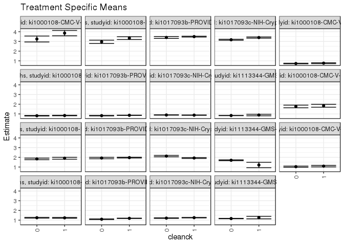

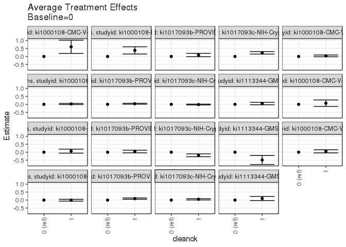

## Results Table

### Parameter: TSM

| agecat | studyid | country | intervention_level | baseline_level | estimate | ci_lower | ci_upper |
| --- | --- | --- | --- | --- | --- | --- | --- |
| 0-3 months | ki1000108-CMC-V-BCS-2002 | INDIA | 0 | NA | 3.2518288 | 2.9438931 | 3.5597644 |
| 0-3 months | ki1000108-CMC-V-BCS-2002 | INDIA | 1 | NA | 3.8579355 | 3.5787981 | 4.1370730 |
| 0-3 months | ki1000108-IRC | INDIA | 0 | NA | 2.9619937 | 2.7885935 | 3.1353939 |
| 0-3 months | ki1000108-IRC | INDIA | 1 | NA | 3.3428748 | 3.1973441 | 3.4884055 |
| 0-3 months | ki1017093b-PROVIDE | BANGLADESH | 0 | NA | 3.4081451 | 3.3109186 | 3.5053716 |
| 0-3 months | ki1017093b-PROVIDE | BANGLADESH | 1 | NA | 3.4981435 | 3.4554661 | 3.5408209 |
| 0-3 months | ki1017093c-NIH-Crypto | BANGLADESH | 0 | NA | 3.1745399 | 3.1236576 | 3.2254222 |
| 0-3 months | ki1017093c-NIH-Crypto | BANGLADESH | 1 | NA | 3.4008014 | 3.3424686 | 3.4591342 |
| 3-6 months | ki1000108-CMC-V-BCS-2002 | INDIA | 0 | NA | 1.7726660 | 1.6356257 | 1.9097063 |
| 3-6 months | ki1000108-CMC-V-BCS-2002 | INDIA | 1 | NA | 1.8445040 | 1.6964825 | 1.9925255 |
| 3-6 months | ki1000108-IRC | INDIA | 0 | NA | 1.8424439 | 1.7603966 | 1.9244912 |
| 3-6 months | ki1000108-IRC | INDIA | 1 | NA | 1.9091738 | 1.8145918 | 2.0037558 |
| 3-6 months | ki1017093b-PROVIDE | BANGLADESH | 0 | NA | 1.9296714 | 1.8557261 | 2.0036166 |
| 3-6 months | ki1017093b-PROVIDE | BANGLADESH | 1 | NA | 1.9729015 | 1.9334627 | 2.0123403 |
| 3-6 months | ki1017093c-NIH-Crypto | BANGLADESH | 0 | NA | 2.1286478 | 2.0540579 | 2.2032376 |
| 3-6 months | ki1017093c-NIH-Crypto | BANGLADESH | 1 | NA | 1.9344184 | 1.8856905 | 1.9831463 |
| 3-6 months | ki1113344-GMS-Nepal | NEPAL | 0 | NA | 1.7027121 | 1.6609278 | 1.7444964 |
| 3-6 months | ki1113344-GMS-Nepal | NEPAL | 1 | NA | 1.2137537 | 0.9349068 | 1.4926005 |
| 6-12 months | ki1000108-CMC-V-BCS-2002 | INDIA | 0 | NA | 1.0391377 | 0.9790397 | 1.0992356 |
| 6-12 months | ki1000108-CMC-V-BCS-2002 | INDIA | 1 | NA | 1.0936958 | 1.0164441 | 1.1709476 |
| 6-12 months | ki1000108-IRC | INDIA | 0 | NA | 1.2499253 | 1.2096925 | 1.2901581 |
| 6-12 months | ki1000108-IRC | INDIA | 1 | NA | 1.2411366 | 1.2010795 | 1.2811936 |
| 6-12 months | ki1017093b-PROVIDE | BANGLADESH | 0 | NA | 1.0959603 | 1.0585926 | 1.1333281 |
| 6-12 months | ki1017093b-PROVIDE | BANGLADESH | 1 | NA | 1.1896856 | 1.1705984 | 1.2087728 |
| 6-12 months | ki1017093c-NIH-Crypto | BANGLADESH | 0 | NA | 1.2098067 | 1.1803213 | 1.2392921 |
| 6-12 months | ki1017093c-NIH-Crypto | BANGLADESH | 1 | NA | 1.2592400 | 1.2315767 | 1.2869034 |
| 6-12 months | ki1113344-GMS-Nepal | NEPAL | 0 | NA | 1.1668512 | 1.1456108 | 1.1880917 |
| 6-12 months | ki1113344-GMS-Nepal | NEPAL | 1 | NA | 1.2662784 | 1.1377752 | 1.3947817 |
| 12-24 months | ki1000108-CMC-V-BCS-2002 | INDIA | 0 | NA | 0.7251247 | 0.6929258 | 0.7573236 |
| 12-24 months | ki1000108-CMC-V-BCS-2002 | INDIA | 1 | NA | 0.7606345 | 0.7146439 | 0.8066252 |
| 12-24 months | ki1000108-IRC | INDIA | 0 | NA | 0.8162762 | 0.7898340 | 0.8427184 |
| 12-24 months | ki1000108-IRC | INDIA | 1 | NA | 0.8400706 | 0.8119085 | 0.8682326 |
| 12-24 months | ki1017093b-PROVIDE | BANGLADESH | 0 | NA | 0.8260344 | 0.7990724 | 0.8529965 |
| 12-24 months | ki1017093b-PROVIDE | BANGLADESH | 1 | NA | 0.8642223 | 0.8509554 | 0.8774892 |
| 12-24 months | ki1017093c-NIH-Crypto | BANGLADESH | 0 | NA | 0.8929927 | 0.8760811 | 0.9099044 |
| 12-24 months | ki1017093c-NIH-Crypto | BANGLADESH | 1 | NA | 0.8787685 | 0.8599665 | 0.8975706 |
| 12-24 months | ki1113344-GMS-Nepal | NEPAL | 0 | NA | 0.8391407 | 0.8225561 | 0.8557252 |
| 12-24 months | ki1113344-GMS-Nepal | NEPAL | 1 | NA | 0.8896664 | 0.8134394 | 0.9658934 |

### Parameter: E(Y)

| agecat | studyid | country | intervention_level | baseline_level | estimate | ci_lower | ci_upper |
| --- | --- | --- | --- | --- | --- | --- | --- |
| 0-3 months | ki1000108-CMC-V-BCS-2002 | INDIA | NA | NA | 3.5235318 | 3.3031217 | 3.7439420 |
| 0-3 months | ki1000108-IRC | INDIA | NA | NA | 3.1808197 | 3.0676645 | 3.2939748 |
| 0-3 months | ki1017093b-PROVIDE | BANGLADESH | NA | NA | 3.4826706 | 3.4434873 | 3.5218539 |
| 0-3 months | ki1017093c-NIH-Crypto | BANGLADESH | NA | NA | 3.3125346 | 3.2707547 | 3.3543144 |
| 3-6 months | ki1000108-CMC-V-BCS-2002 | INDIA | NA | NA | 1.8037880 | 1.7029866 | 1.9045894 |
| 3-6 months | ki1000108-IRC | INDIA | NA | NA | 1.8807708 | 1.8161067 | 1.9454349 |
| 3-6 months | ki1017093b-PROVIDE | BANGLADESH | NA | NA | 1.9654454 | 1.9303798 | 2.0005110 |
| 3-6 months | ki1017093c-NIH-Crypto | BANGLADESH | NA | NA | 2.0125524 | 1.9699507 | 2.0551541 |
| 3-6 months | ki1113344-GMS-Nepal | NEPAL | NA | NA | 1.6958254 | 1.6540818 | 1.7375690 |
| 6-12 months | ki1000108-CMC-V-BCS-2002 | INDIA | NA | NA | 1.0624474 | 1.0146679 | 1.1102268 |
| 6-12 months | ki1000108-IRC | INDIA | NA | NA | 1.2448229 | 1.2160865 | 1.2735593 |
| 6-12 months | ki1017093b-PROVIDE | BANGLADESH | NA | NA | 1.1731762 | 1.1558671 | 1.1904853 |
| 6-12 months | ki1017093c-NIH-Crypto | BANGLADESH | NA | NA | 1.2387386 | 1.2183403 | 1.2591370 |
| 6-12 months | ki1113344-GMS-Nepal | NEPAL | NA | NA | 1.1687097 | 1.1476895 | 1.1897299 |
| 12-24 months | ki1000108-CMC-V-BCS-2002 | INDIA | NA | NA | 0.7397013 | 0.7128622 | 0.7665404 |
| 12-24 months | ki1000108-IRC | INDIA | NA | NA | 0.8300487 | 0.8102720 | 0.8498253 |
| 12-24 months | ki1017093b-PROVIDE | BANGLADESH | NA | NA | 0.8575519 | 0.8455586 | 0.8695452 |
| 12-24 months | ki1017093c-NIH-Crypto | BANGLADESH | NA | NA | 0.8863476 | 0.8737443 | 0.8989509 |
| 12-24 months | ki1113344-GMS-Nepal | NEPAL | NA | NA | 0.8399109 | 0.8235241 | 0.8562976 |

### Parameter: ATE

| agecat | studyid | country | intervention_level | baseline_level | estimate | ci_lower | ci_upper |
| --- | --- | --- | --- | --- | --- | --- | --- |
| 0-3 months | ki1000108-CMC-V-BCS-2002 | INDIA | 0 | 0 | 0.0000000 | 0.0000000 | 0.0000000 |
| 0-3 months | ki1000108-CMC-V-BCS-2002 | INDIA | 1 | 0 | 0.6061067 | 0.1904842 | 1.0217293 |
| 0-3 months | ki1000108-IRC | INDIA | 0 | 0 | 0.0000000 | 0.0000000 | 0.0000000 |
| 0-3 months | ki1000108-IRC | INDIA | 1 | 0 | 0.3808810 | 0.1545035 | 0.6072586 |
| 0-3 months | ki1017093b-PROVIDE | BANGLADESH | 0 | 0 | 0.0000000 | 0.0000000 | 0.0000000 |
| 0-3 months | ki1017093b-PROVIDE | BANGLADESH | 1 | 0 | 0.0899984 | -0.0161824 | 0.1961791 |
| 0-3 months | ki1017093c-NIH-Crypto | BANGLADESH | 0 | 0 | 0.0000000 | 0.0000000 | 0.0000000 |
| 0-3 months | ki1017093c-NIH-Crypto | BANGLADESH | 1 | 0 | 0.2262615 | 0.1488552 | 0.3036677 |
| 3-6 months | ki1000108-CMC-V-BCS-2002 | INDIA | 0 | 0 | 0.0000000 | 0.0000000 | 0.0000000 |
| 3-6 months | ki1000108-CMC-V-BCS-2002 | INDIA | 1 | 0 | 0.0718380 | -0.1298807 | 0.2735566 |
| 3-6 months | ki1000108-IRC | INDIA | 0 | 0 | 0.0000000 | 0.0000000 | 0.0000000 |
| 3-6 months | ki1000108-IRC | INDIA | 1 | 0 | 0.0667299 | -0.0584800 | 0.1919398 |
| 3-6 months | ki1017093b-PROVIDE | BANGLADESH | 0 | 0 | 0.0000000 | 0.0000000 | 0.0000000 |
| 3-6 months | ki1017093b-PROVIDE | BANGLADESH | 1 | 0 | 0.0432301 | -0.0405751 | 0.1270353 |
| 3-6 months | ki1017093c-NIH-Crypto | BANGLADESH | 0 | 0 | 0.0000000 | 0.0000000 | 0.0000000 |
| 3-6 months | ki1017093c-NIH-Crypto | BANGLADESH | 1 | 0 | -0.1942293 | -0.2833251 | -0.1051336 |
| 3-6 months | ki1113344-GMS-Nepal | NEPAL | 0 | 0 | 0.0000000 | 0.0000000 | 0.0000000 |
| 3-6 months | ki1113344-GMS-Nepal | NEPAL | 1 | 0 | -0.4889585 | -0.7709186 | -0.2069984 |
| 6-12 months | ki1000108-CMC-V-BCS-2002 | INDIA | 0 | 0 | 0.0000000 | 0.0000000 | 0.0000000 |
| 6-12 months | ki1000108-CMC-V-BCS-2002 | INDIA | 1 | 0 | 0.0545582 | -0.0433172 | 0.1524335 |
| 6-12 months | ki1000108-IRC | INDIA | 0 | 0 | 0.0000000 | 0.0000000 | 0.0000000 |
| 6-12 months | ki1000108-IRC | INDIA | 1 | 0 | -0.0087888 | -0.0655624 | 0.0479848 |
| 6-12 months | ki1017093b-PROVIDE | BANGLADESH | 0 | 0 | 0.0000000 | 0.0000000 | 0.0000000 |
| 6-12 months | ki1017093b-PROVIDE | BANGLADESH | 1 | 0 | 0.0937253 | 0.0517649 | 0.1356856 |
| 6-12 months | ki1017093c-NIH-Crypto | BANGLADESH | 0 | 0 | 0.0000000 | 0.0000000 | 0.0000000 |
| 6-12 months | ki1017093c-NIH-Crypto | BANGLADESH | 1 | 0 | 0.0494333 | 0.0090025 | 0.0898641 |
| 6-12 months | ki1113344-GMS-Nepal | NEPAL | 0 | 0 | 0.0000000 | 0.0000000 | 0.0000000 |
| 6-12 months | ki1113344-GMS-Nepal | NEPAL | 1 | 0 | 0.0994272 | -0.0308197 | 0.2296741 |
| 12-24 months | ki1000108-CMC-V-BCS-2002 | INDIA | 0 | 0 | 0.0000000 | 0.0000000 | 0.0000000 |
| 12-24 months | ki1000108-CMC-V-BCS-2002 | INDIA | 1 | 0 | 0.0355098 | -0.0206321 | 0.0916517 |
| 12-24 months | ki1000108-IRC | INDIA | 0 | 0 | 0.0000000 | 0.0000000 | 0.0000000 |
| 12-24 months | ki1000108-IRC | INDIA | 1 | 0 | 0.0237944 | -0.0148358 | 0.0624245 |
| 12-24 months | ki1017093b-PROVIDE | BANGLADESH | 0 | 0 | 0.0000000 | 0.0000000 | 0.0000000 |
| 12-24 months | ki1017093b-PROVIDE | BANGLADESH | 1 | 0 | 0.0381879 | 0.0081385 | 0.0682372 |
| 12-24 months | ki1017093c-NIH-Crypto | BANGLADESH | 0 | 0 | 0.0000000 | 0.0000000 | 0.0000000 |
| 12-24 months | ki1017093c-NIH-Crypto | BANGLADESH | 1 | 0 | -0.0142242 | -0.0395130 | 0.0110646 |
| 12-24 months | ki1113344-GMS-Nepal | NEPAL | 0 | 0 | 0.0000000 | 0.0000000 | 0.0000000 |
| 12-24 months | ki1113344-GMS-Nepal | NEPAL | 1 | 0 | 0.0505257 | -0.0274845 | 0.1285360 |